# Initial EDA Basic Outline

Daniel Gao

## Research Question:

How do video games differ in Esports based on earnings, players, and genre?

**Introduction**

The video game industry is growing and one industry that has grown alongside is electronic sports. Electronic sports, otherwise known as Esports, is the competitive aspect of video games where players compete professorially. Either in a team or solo, these players compete against each other in tournaments.

## Data Processing

#### Data Intake

**Importing The Data**

Both datasets “GenralEsportData” and “HistoricalEsportData” were taken from [Kaggle.com](https://www.kaggle.com/datasets/rankirsh/esports-earnings). Since both datasets were CSV files, a read.csv() function was used to read the two files. The results of each read function were then assigned to two data frames “General” and “Historical” respectively.

```r
General <- read.csv("GeneralEsportData.csv")
Historical <- read.csv("HistoricalEsportData.csv")
library(tidyverse)
```

#### Data Wrangling

**General Dataset**:

```r
str(General)
```

```
'data.frame':   631 obs. of  7 variables:
 $ Game            : chr  "Age of Empires" "Age of Empires II" "Age of Empires III" "Age of Empires IV" ...
 $ ReleaseDate     : int  1997 1999 2005 2021 2011 2002 2018 2019 2018 2007 ...
 $ Genre           : chr  "Strategy" "Strategy" "Strategy" "Strategy" ...
 $ TotalEarnings   : num  460831 3042872 113894 893245 8647 ...
 $ OnlineEarnings  : num  334217 1129627 41800 408517 775 ...
 $ TotalPlayers    : int  407 1869 155 442 42 182 14 133 277 936 ...
 $ TotalTournaments: int  227 1481 141 275 43 208 8 52 46 494 ...
```

```r
summary(General)
```

```
     Game            ReleaseDate      Genre           TotalEarnings       OnlineEarnings       TotalPlayers
 Length:631         Min.   :1981   Length:631         Min.   :        0   Min.   :        0   Min.   :    0.0
 Class :character   1st Qu.:2007   Class :character   1st Qu.:     1000   1st Qu.:        0   1st Qu.:    4.0
 Mode  :character   Median :2015   Mode  :character   Median :    32208   Median :    11750   Median :   20.0
                    Mean   :2012                      Mean   :  2374446   Mean   :  1673982   Mean   :  218.2
                    3rd Qu.:2018                      3rd Qu.:   246934   3rd Qu.:   149673   3rd Qu.:   97.0
                    Max.   :2022                      Max.   :314915846   Max.   :281406267   Max.   :15741.0
 TotalTournaments
 Min.   :   0.00
 1st Qu.:   1.00
 Median :   5.00
 Mean   :  91.42
 3rd Qu.:  27.50
 Max.   :7059.00
```

**A little more about the General dataset**:

There are no null values in this data.

```r
colSums(is.na(General))
```

```
            Game      ReleaseDate            Genre    TotalEarnings   OnlineEarnings     TotalPlayers TotalTournaments
               0                0                0                0                0                0                0
```

According to the table and graph, the genre with the highest earning is Multiplayer Online Battle Arena with a total earning of $540,062,582. The genre with the second high earning is First-Pesron Shooter with a total earning of $380,906,784.

```r
General %>%
  group_by(Genre) %>%
  summarise(TotalEarnings = sum(TotalEarnings)) %>%
  arrange(desc(TotalEarnings)) %>%
  head()
```

| Genre | TotalEarnings |
| --- | --- |
| Multiplayer Online Battle Arena | 540062582 |
| First-Person Shooter | 380906784 |
| Battle Royale | 306857313 |
| Strategy | 100369012 |
| Sports | 59183975 |
| Collectible Card Game | 49391606 |

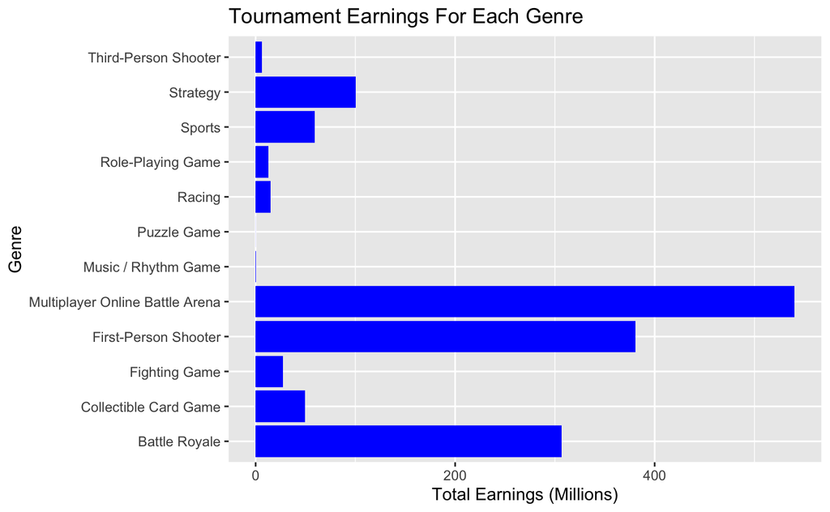

```r
General %>%
  group_by(Genre) %>%
  summarise(TotalEarnings = sum(TotalEarnings)) %>%
  arrange(desc(TotalEarnings)) %>%
  ggplot(aes(x = Genre, y = TotalEarnings/1000000)) +
  geom_col(fill = "blue") +
  coord_flip() +
  ylab("Total Earnings (Millions)") +
  ggtitle("Tournament Earnings For Each Genre")
```

**Historical dataset** The Historical dataset consists of the earnings per month for every game. The dataset contains 5 variables: Date, Game, Earnings, Players, and Tournaments. There are a total of 8751 cases. Each case represents the earning of a game for that month.

```r
str(Historical)
```

```
'data.frame':   8751 obs. of  5 variables:
 $ Date       : chr  "1998-01-01" "1998-05-01" "1998-05-01" "1998-07-01" ...
 $ Game       : chr  "QuakeWorld" "Quake II" "QuakeWorld" "Quake II" ...
 $ Earnings   : num  15000 14600 300 6500 36600 22000 20000 2000 15000 3000 ...
 $ Players    : int  8 4 3 4 13 0 8 1 5 2 ...
 $ Tournaments: int  1 1 1 1 2 1 1 1 1 1 ...
```

*A little more about the Historical dataset* There are no null values in this dataset.

```r
colSums(is.na(Historical))
```

```
       Date        Game    Earnings     Players Tournaments
          0           0           0           0           0
```

According to the table and graph, the game with the highest earnings for all the tournaments was Dota 2 with a total earning of $315,065,846. The game with the second highest earning is Fortnite $155,314,332.

```r
Historical %>%
  group_by(Game) %>%
  summarise(Earnings = sum(Earnings)) %>%
  arrange(desc(Earnings)) %>%
  head()
```

| Game | Earnings |
| --- | --- |
| Dota 2 | 315065846 |
| Fortnite | 155314332 |
| Counter-Strike: Global Offensive | 150477573 |
| League of Legends | 101662548 |
| Arena of Valor | 80088046 |
| PLAYERUNKNOWN'S BATTLEGROUNDS Mobile | 63126780 |

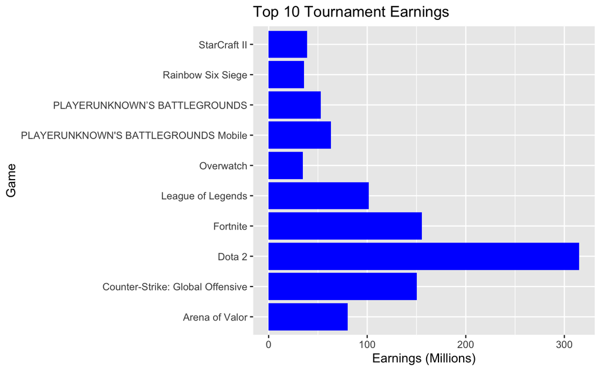

```r
Historical %>%
  group_by(Game) %>%
  summarise(Earnings = sum(Earnings)) %>%
  arrange(desc(Earnings)) %>%
  head(10) %>%
  ggplot(aes(x = Game, y = Earnings / 1000000)) +
  geom_col(fill = "blue") +
  coord_flip() +
  ggtitle("Top 10 Tournament Earnings ") +
  ylab("Earnings (Millions)")
```

**How the data was colletecd**: The creator, Ran.Kirsh, obtain this data from [Esports Earnings](https://www.esportsearnings.com/tournaments). Esports Earning stated, “Sources include news articles, forum posts, live report threads, interviews, official statements, reliable databases, VODs, and other publicly-accessible sources that preserve”historical” information.

## Data Visualization

#### Plot 1

This plot displays the top 10 games with the highest total players in all of their tournaments combined. The game with the highest total of players is Counter Strike Global Offensive. The game with the second-highest total player count is League of Legends. This graph does help in answering my research question, but I will need to modify this graph. The x-axis and y-axis do not are not refined.

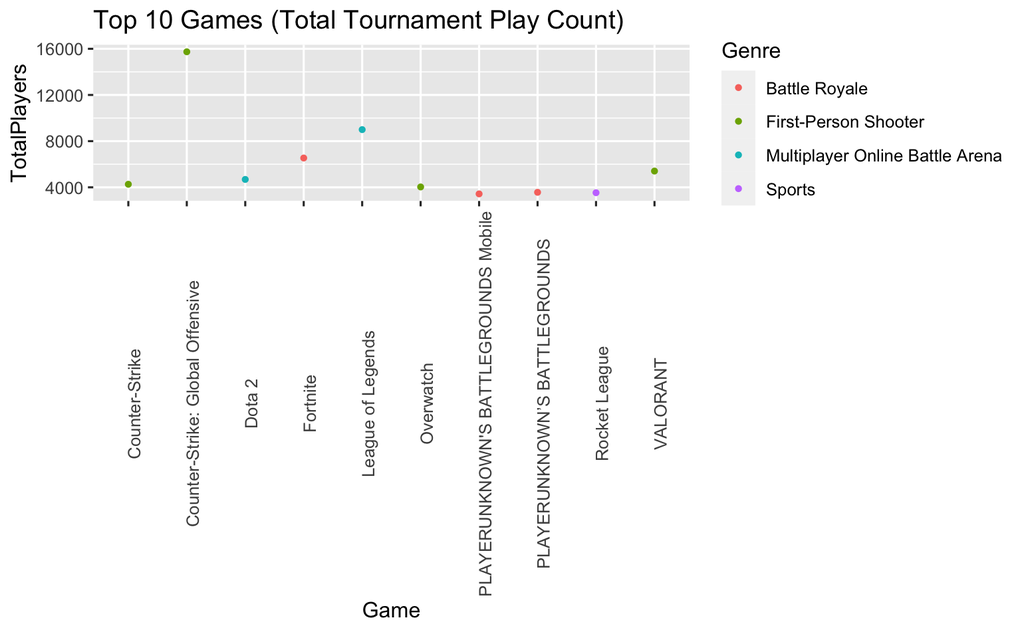

#### Plot 2

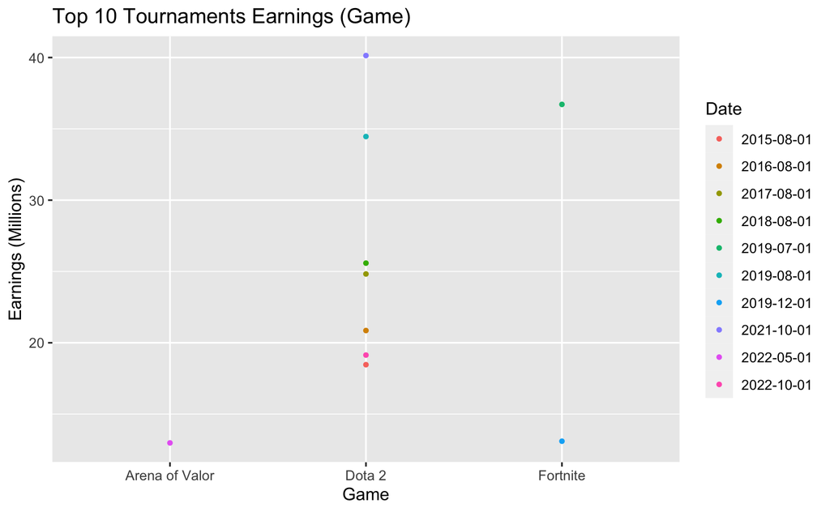

```r
Historical %>%
  arrange(desc(Earnings)) %>%
  head(10) %>%
  ggplot(aes(x = Game, y = Earnings / 1000000, color = Date)) +
  geom_point(shape = "circle", size = 1) +
  ylab("Earnings (Millions)") +
  ggtitle("Top 10 Tournaments Earnings (Game) ")
```

## Conclusion

The answer to my research question is a comparison between earnings, player, and genre. I have been diving into the differences between games in the Esports scene based on earnings, players, and genre. But I have not been able to fully utilize the two datasets in terms of joining the two datasets. I would like the create graph that displays the join also. The graphs are another objective I would like to work on. There some graphs that are not fully refined.